# Sumo: herramienta para emailmarketing

Omar Gonzáles Díaz

2019-05-05

## ¿Qué es sumo?

Sumo es una potente herramienta de email marketing que nos ayuda a generar una lista de todos los usuarios que interactuaron con nuestro sitio, y de una u otra forma se animaron a enviarnos su correo electrónico a nuestra Base de Datos en Sumo.com.

Con esta base de datos, la misma que podemos segmentar (Por ejemplo: usuarios que dejar su correo electrónico porque están interesados en un descuento o usuarios que dejaron su correo electrónico porque están interesados en un producto en concreto).

## Como instalar Sumo

Solo tienes que instalar el código de Sumo en todas las páginas de tu sitio web, en la etiqueta `<head></head>`.

El código a instalar lo proporciona la misma página de SUMO, y lo puedes instalar directamente en las páginas de tu sitio o a través de alguna herramienta como Google Tag Manager (también ofrece integración con Wordpress, Shopify, etc).

El código de Sumo se ve así:

```javascript
<script async>(function(s,u,m,o,j,v){j=u.createElement(m);v=u.getElementsByTagName(m)[0];j.async=1;j.src=o;j.dataset.sumoSiteId='el-id-de-tu-sitio-en-sumo.com';v.parentNode.insertBefore(j,v)})(window,document,'script','//load.sumo.com/');</script>
```

```
<html>
  <head>
    <script async> CÓDIGO DE SUMO </script>
  </head>
  <body>
  </body>
</html>
```

# ¿Cómo usar sumo?

Puedes usar Sumo de modo gratuito o pagando $39 USD mensuales. Para este post vamos a usar la versión gratuita puesto que queremos explorar la herramienta.

En la versión gratuita nos ofrecen las funcionalidades báscias. Esto significa que podemos recolectar los correos de los visitantes a nuestro sitio web, agregarlos a listas, enviarles un correo para agradecerles por haber suscrito a nuestra web; pero, por ejemplo, no podemos personlizar el diseño de el formulario que se muestra.

### Este es un ejemplo real de cómo se muestra Sumo en nuestra página web:

[figure not shown]

Y es lo que les vamos a enseñar en este post.

# Crear un formulario básico:

Lo primero es crear un fomulario básico:

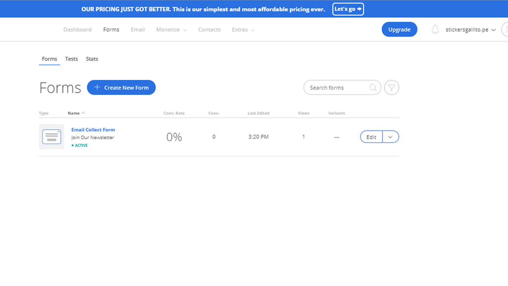

# Diseño del formulario:

[figure not shown]

# Crear la campaña

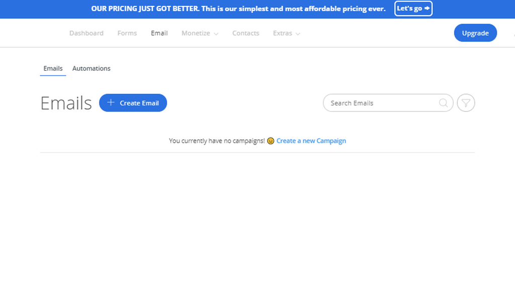

# Reglas:

En cuanto a reglas, en la versión básica encontré varios opciones básicas muy buenas. Entre ellas: mostrar el formulario si es que la url de la imagen es igual a, si el dispositivo desde el que se ve la web es un celular, etc.

[figure not shown]

## Regla por URL (Path) de la página

[figure not shown]

## Regla: mostrar el formulario si el usuario está en la página de inicio o por el contrario si se encuentra en alguna de las secciones

[figure not shown]

## Regla: mostrar el formulario de acuerdo al tipo de dispositvo

[figure not shown]

## Regla: mostrar el formulario si nuestra página generó una determinada cookie

*Esta opción es súper interesante pero solo está disponible para usuarios que pagan por las versión profesional de SUMO.*

[figure not shown]

## Registro en formulario exitoso:

Una vez que el usuario se registró exitosamente en tu sitio web, lo que puedes hacer es:

1. Redireccionarlo a alguna página en tu sitio: la página de inicio o una sección en particular.

[figure not shown]

2. Iniciar automáticamente la descarga de algún archivo para el usuario. Esto es ideal cuando se quiere motivar a los usuarios a registrarse y a cambio se les ofrece un PDF con las últimas tendencias de la industria de su negocio, etc.

[figure not shown]

También pudes configurar un email personalizado que se enviará a cada usuario que se registre. Basicamente sería un email con el logo de tu empresa y algunas palabras de agradecimiento por registrarse (todo esto es personalizable).

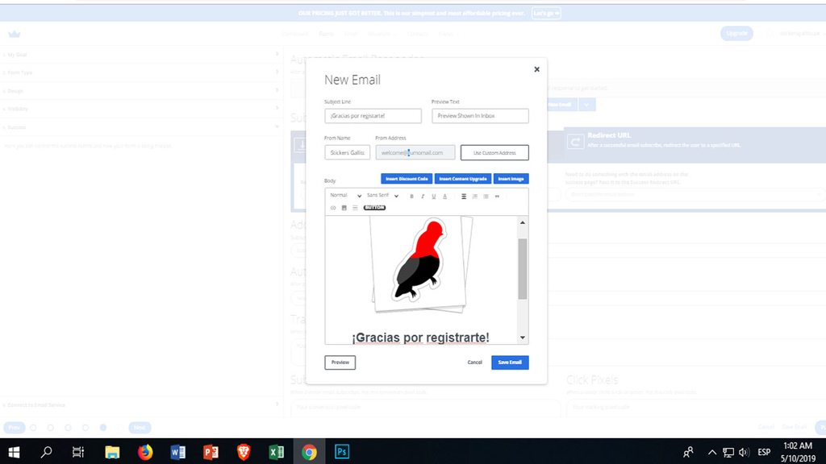

Sin embargo, para lograr esto vas a tener que personalizar algunos registros de tu DNS en el Panel de Control de tu proveedor de hosting:

[figure not shown]